# IsabelaZeberio_100386498_TMFinalAssignment

Isabela Zeberio

2023-03-01

```r
library(dplyr)
library(tidyverse)
library(tidytext)
library(scrapex)
library(rvest)
```

```r
library(httr)
library(tidyr)
library(stringr)
library(ggplot2)
library(xml2)
library(sf)
library(rnaturalearth)
library(scales)
```

## Wes Anderson

Wes Anderson is an American filmmaker known for his distinct visual style, eccentric characters, and idiosyncratic stories. The color palettes of a film can reveal a lot about it. For this project I decided to combine text mining methods and color theory to understand Wes Anderson’s storytelling technique. I will analyze the scripts of three of his most popular films to understand Anderson’s stories through his use of words and color. The objective of this project is to make sense of Anderson’s character development and the core themes of each movie as well as exploring common themes between Rushmore (1998), Fantastic Mr. Fox (2009), and Moonrise Kingdom (2012)

Thanks to `library(wesanderson)` we can access in R to Anderson’s bright and colorful world, but does his script follow this style? Are his characters always cheerful and lively? Is the language he uses always positive? Those who have seen his films know that behind this facade there is something else, but what do the words of his scripts tell us by themselves?

Following Karthik’s package statement, let’s create the most indie final assignment for a course

## Scripts

The first step is to install the `wesanderson` package and save the movie scripts into variables. The [Internet Movie Script Database (IMSDb)](https://imsdb.com/) is a website that offers free scripts for movies, television shows, and other forms of visual media. This database has a collection of scripts for several Wes Anderson films, including “Rushmore”, “Fantastic Mr. Fox”, and “Moonrise Kingdom”.

Installation:

```r
#install.packages("wesanderson")
#or
#devtools::install_github("karthik/wesanderson")

library(wesanderson)
```

All the palettes available:

```r
names(wes_palettes)
```

```
##  [1] "BottleRocket1"  "BottleRocket2"  "Rushmore1"      "Rushmore"
##  [5] "Royal1"         "Royal2"         "Zissou1"        "Darjeeling1"
##  [9] "Darjeeling2"    "Chevalier1"     "FantasticFox1"  "Moonrise1"
## [13] "Moonrise2"      "Moonrise3"      "Cavalcanti1"    "GrandBudapest1"
## [17] "GrandBudapest2" "IsleofDogs1"    "IsleofDogs2"    "FrenchDispatch"
```

In order to convert the scripts into variables we have to read the webpage using `read_html()` and extract the text from. The function `xml_child()` is used to obtain the nodes of the webpage. The instructions are the same for all 3 scripts, it is needed to obtain the character vector with the text of the scripts.

After reading and inspecting [IMSDb](https://imsdb.com/) webpage, I see that the information we want to extract is in the <td> tag with the class scrtext.

- The function `xml_find_all()` allow us to extract the specific nodes containing the screeplay text.
- The function `xml_text()` returns a character vector.
- The function `str_split()` takes the character vector from the previous step and returns a list split by “\r\n” which represent line breaks and indicate us the start of a new line

Character names in a script are frequently written in all capital letters when they are first introduced (e.g., **MAX, CAPTAIN SHARP, LAZY-EYE, FOX**). This is a convention used to help the reader recognize new characters and differentiate them from speech and other components of the script. However, for text analysis, we do not want these names repeating themselves every time a character speaks. Specially since word frequency and the context of words is so important to understand the text. I removed the all capital names with the function `str_replace_all()` to avoid the overrepresentation on the analysis.

The only thing left to do is to remove all the extra space between lines. I used `grepl()` function to search the pattern “^$”, which represents an empty line or blank space, and keep the lines that do not contain the pattern by placing a ! character before `grepl()`.

### Rushmore Academy

```r
raw <- read_html("https://imsdb.com/scripts/Rushmore.html") %>% xml_child()
raw
```

```
## {html_node}
## <head>
##  [1] <meta name="viewport" content="width=device-width, initial-scale=1">\n
##  [2] <meta name="HandheldFriendly" content="true">\n
##  [3] <meta http-equiv="content-type" content="text/html; charset=UTF-8">\n
##  [4] <meta http-equiv="Content-Language" content="EN">\n
##  [5] <meta name="objecttype" content="Document">\n
##  [6] <meta name="ROBOTS" content="INDEX, FOLLOW">\n
##  [7] <meta name="Subject" content="Movie scripts, Film scripts">\n
##  [8] <meta name="rating" content="General">\n
##  [9] <meta name="distribution" content="Global">\n
## [10] <meta name="revisit-after" content="2 days">\n
## [11] <link href="/style.css" rel="stylesheet" type="text/css">\n
## [12] <script type="text/javascript">\r\n  var _gaq = _gaq || [];\r\n  _gaq.pu ...
```

```r
rushmore <- raw %>%
  xml_find_all("//td[@class='scrtext']") %>%
  xml_text() %>%
  str_split("\r\n") %>%
  .[[1]]

rushmore <- rushmore %>%
  str_replace_all(pattern = "^[A-Z[:space:][:punct:]]+$", replacement = "")

rushmore <- rushmore[!grepl("^$", rushmore)] #remove extra spaces

rushmore <- as.data.frame(rushmore[!grepl("^\\s*$", rushmore)]) #create data frame

colnames(rushmore)[1] <- "text" #change the name of the column to next

rushmore <- rushmore %>%
  #include a second column to know from which movie the text comes from
  mutate(movie="Rushmore") %>%
  # Remove the first 3 rows and the last 2 which includes information bout the script but is not text from the script
   slice(4:(nrow(.) - 2))

tibble(rushmore)
```

```
## # A tibble: 1,819 × 2
##    text                                                                    movie
##    <chr>                                                                   <chr>
##  1 A private day school. Twenty 10th grade boys are sitting in desks in g… Rush…
##  2 The teacher, MR. ADAMS, is at the front of the room, finishing a compl… Rush…
##  3 Except when the value of the x coordinate is less than or equal to the… Rush…
##  4 A boy named ISAAC has raised his hand                                   Rush…
##  5 What about that problem?                                                Rush…
##  6 Isaac points to a startling and intricate arrangement of huge numbers … Rush…
##  7 Oh, I really just put that up there as a joke. That's probably the har… Rush…
##  8 How much extra credit is it worth?                                      Rush…
##  9 Well, I've never seen anyone get it right before, including my mentor,… Rush…
## 10 (pause)                                                                 Rush…
## # … with 1,809 more rows
```

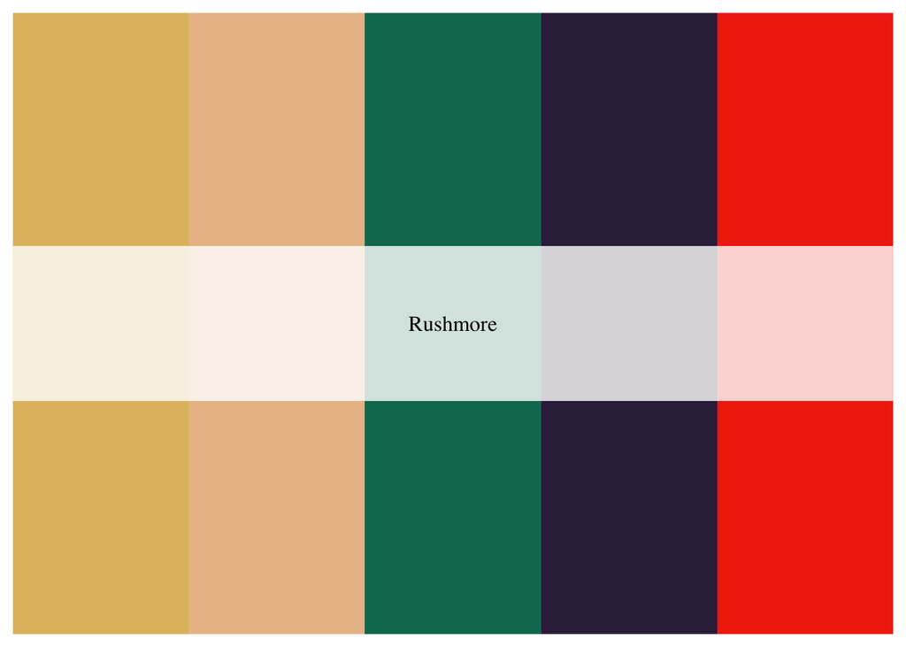

```r
wes_palette("Rushmore")
```

### Moonrise Kingdom

```r
raw <- read_html("https://imsdb.com/scripts/Moonrise-Kingdom.html") %>% xml_child()
raw
```

```
## {html_node}
## <head>
##  [1] <meta name="viewport" content="width=device-width, initial-scale=1">\n
##  [2] <meta name="HandheldFriendly" content="true">\n
##  [3] <meta http-equiv="content-type" content="text/html; charset=UTF-8">\n
##  [4] <meta http-equiv="Content-Language" content="EN">\n
##  [5] <meta name="objecttype" content="Document">\n
##  [6] <meta name="ROBOTS" content="INDEX, FOLLOW">\n
##  [7] <meta name="Subject" content="Movie scripts, Film scripts">\n
##  [8] <meta name="rating" content="General">\n
##  [9] <meta name="distribution" content="Global">\n
## [10] <meta name="revisit-after" content="2 days">\n
## [11] <link href="/style.css" rel="stylesheet" type="text/css">\n
## [12] <script type="text/javascript">\r\n  var _gaq = _gaq || [];\r\n  _gaq.pu ...
```

```r
# Search for all <p> tags with that class in the document
moonrise <- raw %>%
  xml_find_all("//td[@class='scrtext']") %>%
  xml_text() %>%
  str_split("\r\n") %>%
  .[[1]]

moonrise <- moonrise %>%
  str_replace_all(pattern = "^[A-Z[:space:][:punct:]]+$", replacement = "")

moonrise <- moonrise[!grepl("^$", moonrise)] #remove extra spaces

moonrise <- as.data.frame(moonrise[!grepl("^\\s*$", moonrise)])

colnames(moonrise)[1]  <- "text"

moonrise <- moonrise %>%
  mutate(movie="Moonrise Kingdom") %>%
  slice(4:(nrow(.) - 2))

tibble(moonrise)
```

```
## # A tibble: 3,149 × 2
##    text                                                                    movie
##    <chr>                                                                   <chr>
##  1 "          A landing at the top of a crooked, wooden staircase. There … Moon…
##  2 "          a threadbare, braided rug on the floor. There is a long, wi… Moon…
##  3 "          corridor decorated with faded paintings of sailboats and"    Moon…
##  4 "          battleships. The wallpapers are sun-bleached and peeling at" Moon…
##  5 "          the corners except for a few newly-hung strips which are"    Moon…
##  6 "          clean and bright. A small easel sits stored in the corner."  Moon…
##  7 "          Outside, a hard rain falls, drumming the roof and rattling"  Moon…
##  8 "          the gutters."                                                Moon…
##  9 "          A ten-year-old boy in pajamas comes up the steps carefully"  Moon…
## 10 "          eating a bowl of cereal as he walks. He is Lionel. Lionel"   Moon…
## # … with 3,139 more rows
```

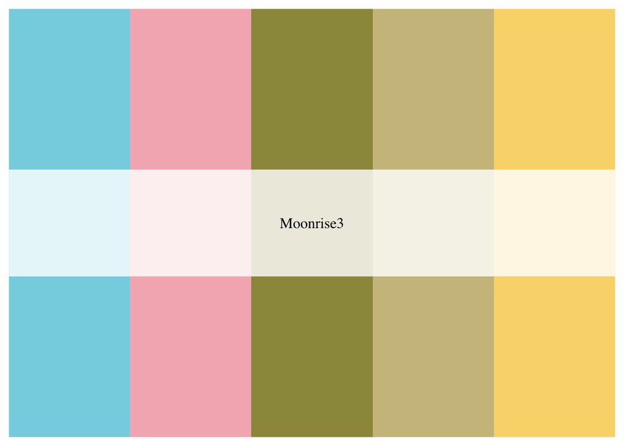

```r
wes_palette("Moonrise3")
```

### Fantastic Mr. Fox

```r
raw <- read_html("https://imsdb.com/scripts/Fantastic-Mr-Fox.html") %>% xml_child()
raw
```

```
## {html_node}
## <head>
##  [1] <meta name="viewport" content="width=device-width, initial-scale=1">\n
##  [2] <meta name="HandheldFriendly" content="true">\n
##  [3] <meta http-equiv="content-type" content="text/html; charset=UTF-8">\n
##  [4] <meta http-equiv="Content-Language" content="EN">\n
##  [5] <meta name="objecttype" content="Document">\n
##  [6] <meta name="ROBOTS" content="INDEX, FOLLOW">\n
##  [7] <meta name="Subject" content="Movie scripts, Film scripts">\n
##  [8] <meta name="rating" content="General">\n
##  [9] <meta name="distribution" content="Global">\n
## [10] <meta name="revisit-after" content="2 days">\n
## [11] <link href="/style.css" rel="stylesheet" type="text/css">\n
## [12] <script type="text/javascript">\r\n  var _gaq = _gaq || [];\r\n  _gaq.pu ...
```

```r
# Search for all <p> tags with that class in the document
fox <- raw %>%
  xml_find_all("//td[@class='scrtext']") %>%
  xml_text() %>%
  str_split("\r\n") %>%
  .[[1]]

fox <- fox %>%
  str_replace_all(pattern = "^[A-Z[:space:][:punct:]]+$", replacement = "")

fox <- fox[!grepl("^$", fox)] #remove extra spaces

fox <- as.data.frame(fox[!grepl("^\\s*$", fox)])

colnames(fox)[1]  <- "text"

fox <- fox %>%
  mutate(movie="Fantastic Mr. Fox") %>%
  slice(4:(nrow(.) - 2))

tibble(fox)
```

```
## # A tibble: 2,776 × 2
##    text                                                                    movie
##    <chr>                                                                   <chr>
##  1 "          An apple tree stands alone at the top of a hill. A handsome" Fant…
##  2 "          fox dressed in an Edwardian-style navy velvet suit leans"    Fant…
##  3 "          against it with his arms folded and his legs crossed, chewi… Fant…
##  4 "          on a reed of wild grass. He holds an apple core in his paw." Fant…
##  5 "          He spits out a seed. He looks off across a meadow that"      Fant…
##  6 "          descends into the valley below."                             Fant…
##  7 "          A female fox strides briskly up the hill. Her coat is a"     Fant…
##  8 "          paler, especially beautiful shade of fox-red, and she wears" Fant…
##  9 "          men's trousers and a dark tunic. Fox says as she approaches… Fant…
## 10 "          What'd the doctor say?"                                      Fant…
## # … with 2,766 more rows
```

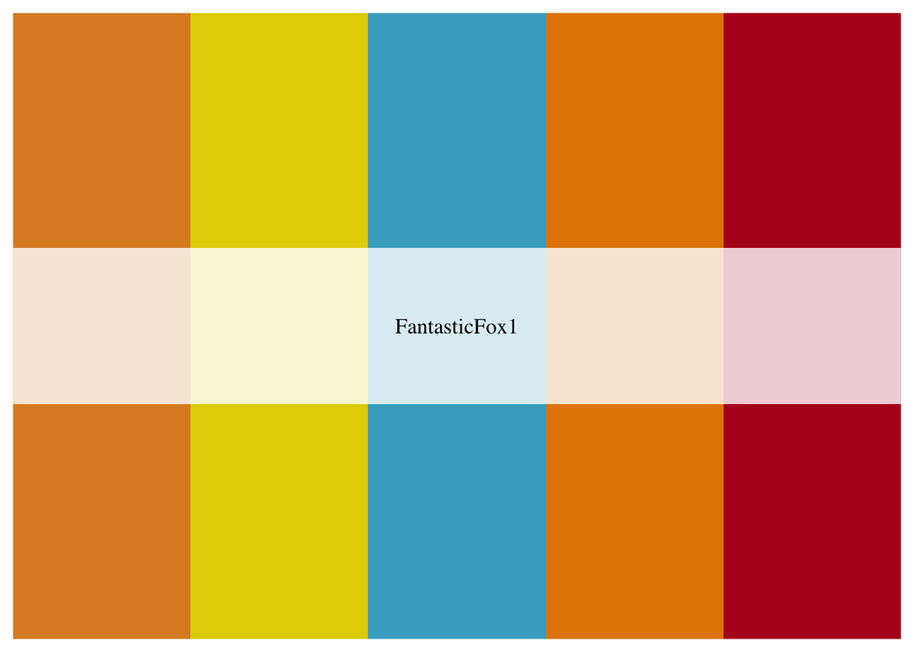

```r
wes_palette("FantasticFox1")
```

```r
script <- rbind(moonrise,fox,rushmore) #I combine in one variable the thee scripts
unique(script$movie)
```

```
## [1] "Moonrise Kingdom"  "Fantastic Mr. Fox" "Rushmore"
```

After obtaining the text from each script and taking a first look at the colors of each film, we can finally start with the text analysis.

## Tokenization

As we saw in class, tokenization is the process of breaking down a piece of text into individual units called tokens, which are meaningful units of text

```r
wes_script <- script %>%
  unnest_tokens(word, text)
```

Stop words have grammatical meaning but do not add to text mining (e.g.,“the”, “or”, “a”). Thus the next step is to filter them by using `anti_join()`

```r
wes_script <- wes_script %>%
  anti_join(stop_words)
```

## Counting word frequencies

We want to know how many times a word is mentioned in Anderson’s movies, so we use the function `count()`.

```r
wes_script %>%
  filter(movie =="Rushmore") %>%
  count(movie, word, sort = TRUE)
```

```
##      movie    word   n
## 1 Rushmore     max 487
## 2 Rushmore   blume 215
## 3 Rushmore    miss 128
## 4 Rushmore   cross 125
## 5 Rushmore    dirk  87
## 6 Rushmore fischer  67
##  [ reached 'max' / getOption("max.print") -- omitted 2543 rows ]
```

In Rushmore we see that the two most frequent words are Max and Blume, character names. The next two are a little bit confusing if you have not seen the movies since the other really important character of this movie is Miss Rosemary Cross.

After the names of the characters, the most repeated words that begin to give us some clues about the overall tone of this film are dirk, pause, nods, smiles, silence, hands, starts, eyes, and school. Many of the words we see describe the actions ore movement the actors have to follow. However, we can perceive in this first reading a contemplative, intimate or introspective tone with moments of silence, nods, and eye contact indicating characters are reflecting on their thoughts and feelings. The world school is also a great indicator of where this story takes place.

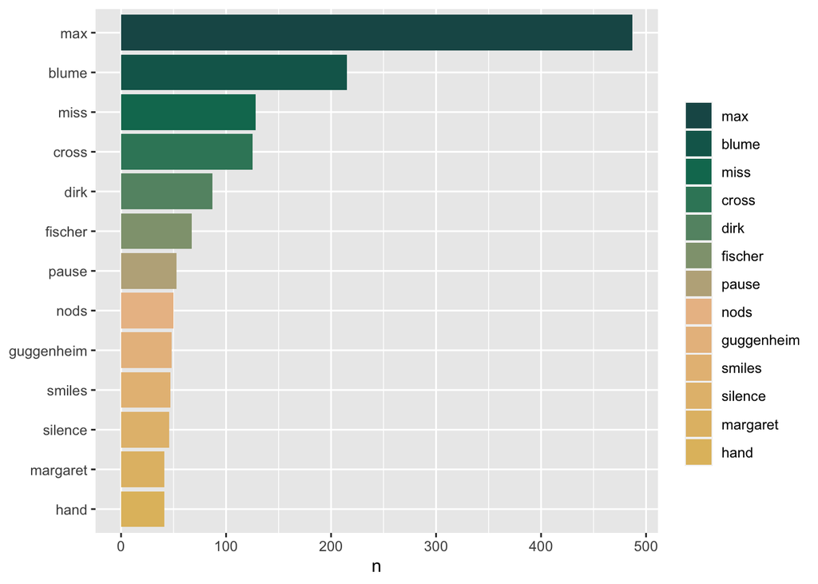

```r
wes_script %>%
  filter(movie =="Rushmore") %>%
  count(movie, word, sort = TRUE) %>%
  #only words mentioned more than 35 times in the script
  filter(n >= 40) %>%
  #we reorder words by number of mentions
  mutate(word = reorder(word, n)) %>%
  #we create the plot with the word (x) and the number of mentions (y)
  ggplot(aes(n, word,  fill = word)) +
  geom_col() +
  labs(y = NULL) +
  scale_fill_manual(values = wes_palette(21, name = "Rushmore", type = "continuous"), name = "") +
  #reverse the order of the legend
  guides(fill = guide_legend(reverse = TRUE))
```

```r
wes_script %>%
  filter(movie =="Moonrise Kingdom") %>%
  count(movie,word, sort = TRUE)
```

```
##              movie    word   n
## 1 Moonrise Kingdom     sam 285
## 2 Moonrise Kingdom    suzy 238
## 3 Moonrise Kingdom   scout 193
## 4 Moonrise Kingdom  master 157
## 5 Moonrise Kingdom captain 146
## 6 Moonrise Kingdom    ward 141
##  [ reached 'max' / getOption("max.print") -- omitted 3399 rows ]
```

In the case of Moonrise Kingdom, we see that, once again, the two most common words are our main characters’ names: Sam and Suzy. However, the third word, scout, is a really good hint about who the main characters are. and as was also the case with Rusmore, we find some words that seem to point to something but are character names: Scout Master Randy Ward, Captain Sharp or Skotak. Nonetheless, the words also show the hierarchical ranking organization like the Scouts normally use. The division of power and the names used by the Scouts comes from the military, thus the use of words like troop, services or commander fits in the scenario where this story takes place.

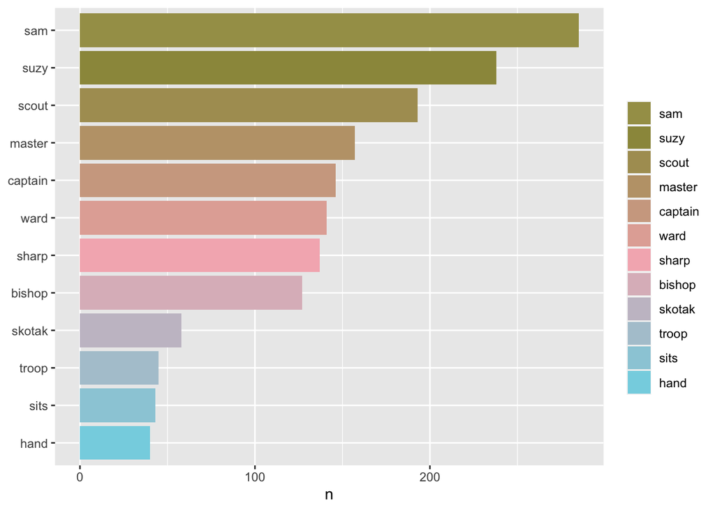

```r
wes_script %>%
  filter(movie =="Moonrise Kingdom") %>%
  count(movie, word, sort = TRUE) %>%
  filter(n >= 40) %>%
  mutate(word = reorder(word, n)) %>%
  ggplot(aes(n, word,  fill = word)) +
  geom_col() +
  labs(y = NULL) +
  scale_fill_manual(values = wes_palette(21, name = "Moonrise3", type = "continuous"), name = "") +
  guides(fill = guide_legend(reverse = TRUE))
```

```r
wes_script %>%
  filter(movie =="Fantastic Mr. Fox") %>%
  count(movie,word, sort = TRUE)
```

```
##               movie          word   n
## 1 Fantastic Mr. Fox           fox 488
## 2 Fantastic Mr. Fox         kylie 145
## 3 Fantastic Mr. Fox           ash 119
## 4 Fantastic Mr. Fox          bean  79
## 5 Fantastic Mr. Fox kristofferson  73
## 6 Fantastic Mr. Fox        badger  64
##  [ reached 'max' / getOption("max.print") -- omitted 3146 rows ]
```

In our third script, we also find as the most frequent words charter names but, moreover, the species of the protagonists: the fox. After these words we find more earthy concepts than in the previous scripts: hole, rat, paw, farmers, apple, chicken, air, tree, cider, mountain, and cuss. The protagonist of this movie are animals, not human, and because they are “anthropomorphic animals” we see a mix of human and animal/nature concepts of the script.

But, what does *cuss* means?

```r
fox %>%
  filter(str_detect(text, "cuss"))
```

```
##                                                   text             movie
## 1                Oh, cuss. What time is it? I'm sorry. Fantastic Mr. Fox
## 2               stinks like cuss, plus moving into the Fantastic Mr. Fox
## 3                Bull-cuss! I'm sugar-coating it, man! Fantastic Mr. Fox
## 4             the biggest cusshole I've ever met in my Fantastic Mr. Fox
## 5                                    The cuss you are! Fantastic Mr. Fox
## 6                                       The cuss am I? Fantastic Mr. Fox
## 7                           Don't cussing point at me! Fantastic Mr. Fox
## 8                             Are you cussing with me? Fantastic Mr. Fox
## 9                 Do I look like I'm cussing with you? Fantastic Mr. Fox
## 10           A few beagles, as we discussed, but we're Fantastic Mr. Fox
## 11             What the cuss? Where'd this giant fence Fantastic Mr. Fox
## 12                           I said one bite, cuss it! Fantastic Mr. Fox
## 13             Holy cuss! They opened the gate! Follow Fantastic Mr. Fox
## 14           Where the cuss does that kid get off? Can Fantastic Mr. Fox
```

[output cut: 29 more lines]

Cuss is a great word to analyze. For non-native English speakers it does not make a lot of sense if we see the word by itself. We need the context of this word to understand what it means. When we read the whole sentence we realize that cuss is used for cursing, it seems like a family-friendly substitute for fuck or shit.

- Oh cuss. What time is it?
- Stinks like cuss
- Bull-cuss!
- The cuss you are!
- Are you cussing with me?
- Let’s kick some fox cuss!

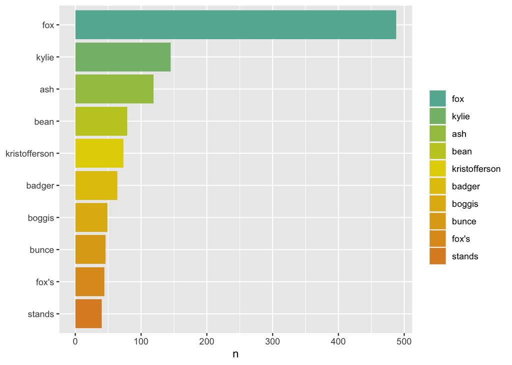

```r
wes_script %>%
  filter(movie =="Fantastic Mr. Fox") %>%
  count(movie, word, sort = TRUE) %>%
  filter(n >= 40) %>%
  mutate(word = reorder(word, n)) %>%
  ggplot(aes(n, word,  fill = word)) +
  geom_col() +
  labs(y = NULL) +
  scale_fill_manual(values = wes_palette(21, name = "FantasticFox1", type = "continuous"), name = "") +
  guides(fill = guide_legend(reverse = TRUE))
```

### Comparing the scripts

Anderson’s scripts often feature highly specific and detailed descriptions of settings and characters, which help to create a strong sense of visual style and tone.

```r
frequency <- wes_script %>%
  mutate(word = str_extract(word, "[a-z']+")) %>%
  #we count number of mentions of a word in each movie
  count(movie, word) %>%
  #we calculate proportion
  group_by(movie) %>%
  mutate(proportion = n / sum(n)) %>%
  select(-n) %>%
  #we reshape the dataframe
  #pivot wider means: more columns, less rows
  pivot_wider(names_from = movie, values_from = proportion) %>%
  #pivot longer means: more rows, less columns
  pivot_longer(`Moonrise Kingdom`:`Fantastic Mr. Fox`,
               names_to = "movie", values_to = "proportion")

frequency
```

```
## # A tibble: 12,234 × 4
##    word        Rushmore movie             proportion
##    <chr>          <dbl> <chr>                  <dbl>
##  1 a          NA        Moonrise Kingdom   0.0000952
##  2 a          NA        Fantastic Mr. Fox  0.000563
##  3 abruptly   NA        Moonrise Kingdom   0.000190
##  4 abruptly   NA        Fantastic Mr. Fox  0.000225
##  5 accent      0.000505 Moonrise Kingdom  NA
##  6 accent      0.000505 Fantastic Mr. Fox  0.000225
##  7 accountant NA        Moonrise Kingdom  NA
##  8 accountant NA        Fantastic Mr. Fox  0.000113
##  9 achilles   NA        Moonrise Kingdom  NA
## 10 achilles   NA        Fantastic Mr. Fox  0.000113
## # … with 12,224 more rows
```

There is a column named “Rushmore” with proportion of the movie because it is our reference. We are comparing the words used in Moonrise Kingdom and Fantastic Mr. Fox with the ones used in Rushmore.

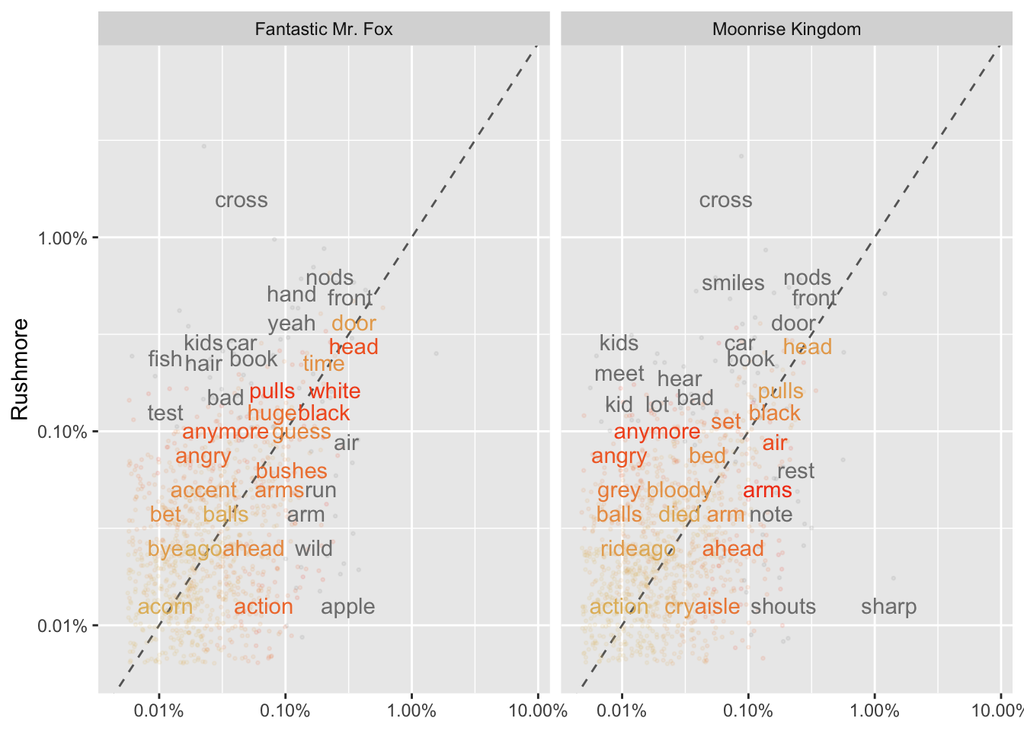

```r
ggplot(frequency, aes(x = proportion, y = `Rushmore`,
                      color = abs(`Rushmore` - proportion))) +
    geom_abline(color = "gray40", lty = 2) +
    geom_jitter(alpha = 0.1, size = 0.5, width = 0.3, height = 0.3) +
    geom_text(aes(label = word), check_overlap = TRUE, vjust = 0.5) +
    scale_x_log10(labels = percent_format()) +
    scale_y_log10(labels = percent_format()) +
    scale_color_gradient(limits = c(0, 0.001),
                         low = wes_palette("Rushmore", n = 20, type = "continuous")[1],
                         high = wes_palette("Rushmore", n = 20, type = "continuous")[20])  +
    facet_wrap(~movie, ncol = 2) +
    theme(legend.position="none") +
    labs(y = "Rushmore", x = NULL)
```

### Word correlation

The Pearson correlation allow us to quantify how similar and different these sets of word frequencies are. This correlation will return a number between -1 and 1 that measures the strength and direction of the relationship between two variables.

```r
cor.test(data = frequency[frequency$movie == "Fantastic Mr. Fox",],
         ~ proportion + `Rushmore`)
```

```
##
##  Pearson's product-moment correlation
##
## data:  proportion and Rushmore
## t = 13.498, df = 1035, p-value < 2.2e-16
## alternative hypothesis: true correlation is not equal to 0
## 95 percent confidence interval:
##  0.3338913 0.4374762
## sample estimates:
##       cor
## 0.3869036
```

```r
cor.test(data = frequency[frequency$movie == "Moonrise Kingdom",],
         ~ proportion + `Rushmore`)
```

```
##
##  Pearson's product-moment correlation
##
## data:  proportion and Rushmore
## t = 12.1, df = 1123, p-value < 2.2e-16
## alternative hypothesis: true correlation is not equal to 0
## 95 percent confidence interval:
##  0.2868543 0.3903059
## sample estimates:
##       cor
## 0.3396068
```

Both Moonrise Kingdom and Fantastic Mr. Fox are weakly correlated to Rushmore, being Fantastic Mr. Fox (0.388) a little more correlated to Rushmore than Moonrise Kingdom (0.339).

## Sentiment analysis

Sentiment analysis is a natural language processing technique to determine the emotional tone of the content. In this case, the goal is to determine whether the scripts are expressing a positive, negative, or neutral sentiment.

Using sentiment analysis on Wes Anderson’s scripts could reveal information about the emotional tone of his films. Wes Anderson’s films are noted for their quirky and enchanting style, and sentiment analysis could contribute to uncovering the underlying emotional themes that run throughout his films.

### Joy words

Let’s find out which are the most common words of joy in Rushmore, Moonrise Kingdom, and in Fantastic Mr. Fox

```r
#we set nrc lexicon to a variable, filtering by joy
nrc_joy <- get_sentiments("nrc") %>%
  filter(sentiment == "joy")
```

```r
rushmore_joy <- wes_script %>%
  filter(movie =="Rushmore") %>%
    #we combine both lists, NRC and Rushmore's words
  inner_join(nrc_joy) %>%
    #we count the mentions of each word to find the most frequent
  count(word, sort = TRUE)
rushmore_joy
```

```
##         word  n
## 1       love 16
## 2     friend 15
## 3       tree 10
## 4     mother  8
## 5   applause  7
## 6      dance  7
## 7    smiling  6
## 8  beautiful  5
## 9       food  5
## 10  football  5
##  [ reached 'max' / getOption("max.print") -- omitted 72 rows ]
```

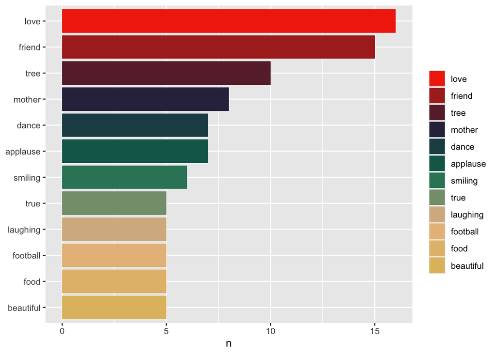

```r
rushmore_joy %>%
  filter(n > 4) %>%
  mutate(word = reorder(word, n)) %>%
  ggplot(aes(x = n, y = word, fill=word)) +
  geom_col() +
  labs(y = NULL) +
  scale_fill_manual(values = wes_palette(12, name = "Rushmore", type = "continuous"), name = "") +
  guides(fill = guide_legend(reverse = TRUE))
```

```r
moonrise_joy <- wes_script %>%
  filter(movie =="Moonrise Kingdom") %>%
  inner_join(nrc_joy) %>%
  count(word, sort = TRUE)
moonrise_joy
```

```
##       word  n
## 1     tree 15
## 2   kitten 13
## 3    beach 11
## 4   church 11
## 5  finally 10
## 6    music  8
## 7     love  7
## 8     true  7
## 9     cove  6
## 10    jump  6
##  [ reached 'max' / getOption("max.print") -- omitted 74 rows ]
```

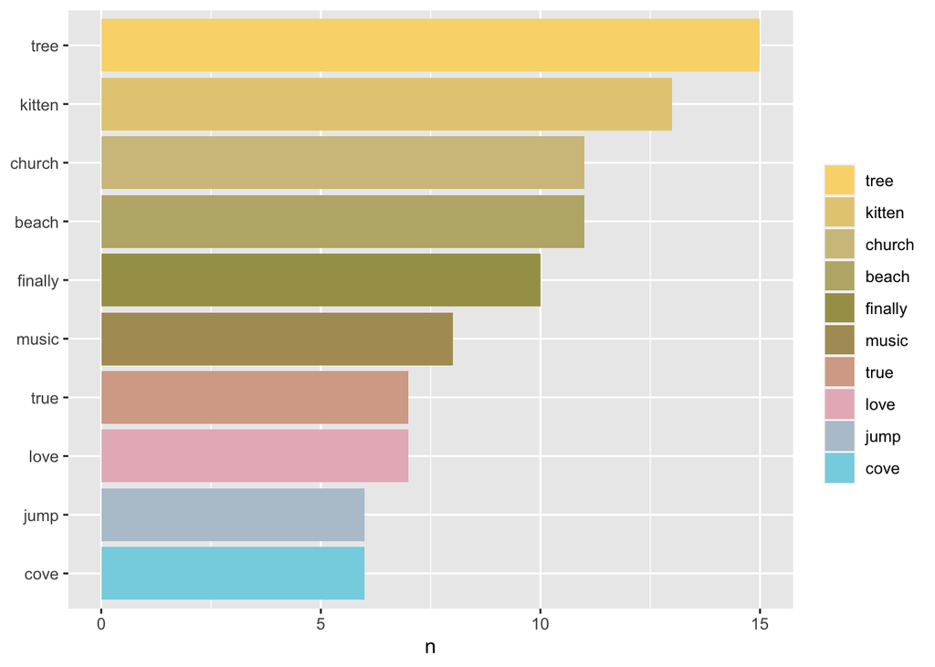

```r
moonrise_joy %>%
  filter(n > 5) %>%
  mutate(word = reorder(word, n)) %>%
  ggplot(aes(x = n, y = word, fill=word)) +
  geom_col() +
  labs(y = NULL) +
  scale_fill_manual(values = wes_palette(10, name = "Moonrise3", type = "continuous"), name = "") +
  guides(fill = guide_legend(reverse = TRUE))
```

```r
fox_joy <- wes_script %>%
  filter(movie =="Fantastic Mr. Fox") %>%
  inner_join(nrc_joy) %>%
  count(word, sort = TRUE)
fox_joy
```

```
##         word  n
## 1       tree 26
## 2      toast  7
## 3       jump  6
## 4  beautiful  5
## 5       love  5
## 6      alive  4
## 7      dance  4
## 8   ecstatic  4
## 9   felicity  4
## 10      food  4
##  [ reached 'max' / getOption("max.print") -- omitted 84 rows ]
```

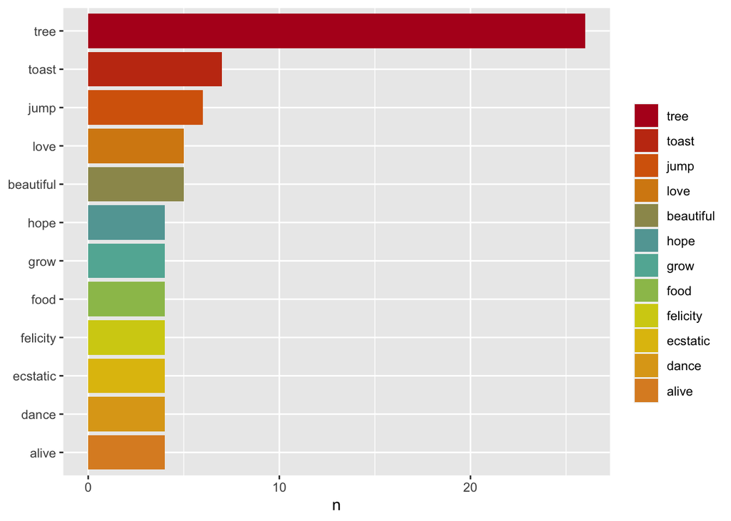

```r
fox_joy %>%
  filter(n > 3) %>%
  mutate(word = reorder(word, n)) %>%
  ggplot(aes(x = n, y = word, fill=word)) +
  geom_col() +
  labs(y = NULL) +
  scale_fill_manual(values = wes_palette(12, name = "FantasticFox1", type = "continuous"), name = "") +
  guides(fill = guide_legend(reverse = TRUE))
```

In addition, Anderson’s scripts often incorporate elements of comedy, drama, and whimsy, blending these genres in unique and unexpected ways.